# Risk Factor Analysis

## Outcome Variable

**Outcome Variable:** wast_rec90d

## Predictor Variables

**Intervention Variable:** feducyrs

**Adjustment Set:**

- arm
- W_mage
- meducyrs
- hhwealth_quart
- W_mhtcm
- W_gagebrth
- W_birthwt
- W_birthlen
- single
- delta_W_mage
- delta_meducyrs
- delta_hhwealth_quart
- delta_W_mhtcm
- delta_W_gagebrth
- delta_W_birthwt
- delta_W_birthlen
- delta_single

## Stratifying Variables

The analysis was stratified on these variable(s):

- agecat
- studyid
- country

## Data Summary

| agecat | studyid | country | feducyrs | wast_rec90d | n_cell | n |
| --- | --- | --- | --- | --- | --- | --- |
| 0-24 months | ki0047075b-MAL-ED | BANGLADESH | High | 0 | 6 | 70 |
| 0-24 months | ki0047075b-MAL-ED | BANGLADESH | High | 1 | 12 | 70 |
| 0-24 months | ki0047075b-MAL-ED | BANGLADESH | Low | 0 | 9 | 70 |
| 0-24 months | ki0047075b-MAL-ED | BANGLADESH | Low | 1 | 18 | 70 |
| 0-24 months | ki0047075b-MAL-ED | BANGLADESH | Medium | 0 | 10 | 70 |
| 0-24 months | ki0047075b-MAL-ED | BANGLADESH | Medium | 1 | 15 | 70 |
| 0-24 months | ki0047075b-MAL-ED | INDIA | High | 0 | 7 | 103 |
| 0-24 months | ki0047075b-MAL-ED | INDIA | High | 1 | 21 | 103 |
| 0-24 months | ki0047075b-MAL-ED | INDIA | Low | 0 | 16 | 103 |
| 0-24 months | ki0047075b-MAL-ED | INDIA | Low | 1 | 31 | 103 |
| 0-24 months | ki0047075b-MAL-ED | INDIA | Medium | 0 | 15 | 103 |
| 0-24 months | ki0047075b-MAL-ED | INDIA | Medium | 1 | 13 | 103 |
| 0-24 months | ki0047075b-MAL-ED | NEPAL | High | 0 | 2 | 34 |
| 0-24 months | ki0047075b-MAL-ED | NEPAL | High | 1 | 9 | 34 |
| 0-24 months | ki0047075b-MAL-ED | NEPAL | Low | 0 | 2 | 34 |
| 0-24 months | ki0047075b-MAL-ED | NEPAL | Low | 1 | 9 | 34 |
| 0-24 months | ki0047075b-MAL-ED | NEPAL | Medium | 0 | 4 | 34 |
| 0-24 months | ki0047075b-MAL-ED | NEPAL | Medium | 1 | 8 | 34 |
| 0-24 months | ki0047075b-MAL-ED | PERU | High | 0 | 2 | 25 |
| 0-24 months | ki0047075b-MAL-ED | PERU | High | 1 | 8 | 25 |
| 0-24 months | ki0047075b-MAL-ED | PERU | Low | 0 | 1 | 25 |
| 0-24 months | ki0047075b-MAL-ED | PERU | Low | 1 | 3 | 25 |
| 0-24 months | ki0047075b-MAL-ED | PERU | Medium | 0 | 1 | 25 |
| 0-24 months | ki0047075b-MAL-ED | PERU | Medium | 1 | 10 | 25 |
| 0-24 months | ki0047075b-MAL-ED | SOUTH AFRICA | High | 0 | 2 | 28 |
| 0-24 months | ki0047075b-MAL-ED | SOUTH AFRICA | High | 1 | 7 | 28 |
| 0-24 months | ki0047075b-MAL-ED | SOUTH AFRICA | Low | 0 | 3 | 28 |
| 0-24 months | ki0047075b-MAL-ED | SOUTH AFRICA | Low | 1 | 8 | 28 |
| 0-24 months | ki0047075b-MAL-ED | SOUTH AFRICA | Medium | 0 | 1 | 28 |
| 0-24 months | ki0047075b-MAL-ED | SOUTH AFRICA | Medium | 1 | 7 | 28 |

[output cut: 330 more lines]

The following strata were considered:

- agecat: 0-24 months, studyid: ki0047075b-MAL-ED, country: BANGLADESH
- agecat: 0-24 months, studyid: ki0047075b-MAL-ED, country: INDIA
- agecat: 0-24 months, studyid: ki0047075b-MAL-ED, country: NEPAL
- agecat: 0-24 months, studyid: ki0047075b-MAL-ED, country: PERU
- agecat: 0-24 months, studyid: ki0047075b-MAL-ED, country: SOUTH AFRICA
- agecat: 0-24 months, studyid: ki0047075b-MAL-ED, country: TANZANIA, UNITED REPUBLIC OF
- agecat: 0-24 months, studyid: ki1000304b-SAS-CompFeed, country: INDIA
- agecat: 0-24 months, studyid: ki1000304b-SAS-FoodSuppl, country: INDIA
- agecat: 0-24 months, studyid: ki1017093b-PROVIDE, country: BANGLADESH
- agecat: 0-24 months, studyid: ki1017093c-NIH-Crypto, country: BANGLADESH
- agecat: 0-24 months, studyid: ki1066203-TanzaniaChild2, country: TANZANIA, UNITED REPUBLIC OF
- agecat: 0-24 months, studyid: ki1113344-GMS-Nepal, country: NEPAL
- agecat: 0-24 months, studyid: ki1119695-PROBIT, country: BELARUS
- agecat: 0-24 months, studyid: ki1126311-ZVITAMBO, country: ZIMBABWE
- agecat: 0-24 months, studyid: ki1135781-COHORTS, country: GUATEMALA
- agecat: 0-24 months, studyid: ki1135781-COHORTS, country: INDIA
- agecat: 0-24 months, studyid: ki1135781-COHORTS, country: PHILIPPINES
- agecat: 0-24 months, studyid: ki1148112-LCNI-5, country: MALAWI
- agecat: 0-24 months, studyid: kiGH5241-JiVitA-3, country: BANGLADESH
- agecat: 0-24 months, studyid: kiGH5241-JiVitA-4, country: BANGLADESH
- agecat: 0-6 months, studyid: ki0047075b-MAL-ED, country: BANGLADESH
- agecat: 0-6 months, studyid: ki0047075b-MAL-ED, country: INDIA
- agecat: 0-6 months, studyid: ki0047075b-MAL-ED, country: NEPAL
- agecat: 0-6 months, studyid: ki0047075b-MAL-ED, country: PERU
- agecat: 0-6 months, studyid: ki0047075b-MAL-ED, country: SOUTH AFRICA
- agecat: 0-6 months, studyid: ki0047075b-MAL-ED, country: TANZANIA, UNITED REPUBLIC OF
- agecat: 0-6 months, studyid: ki1000304b-SAS-CompFeed, country: INDIA
- agecat: 0-6 months, studyid: ki1000304b-SAS-FoodSuppl, country: INDIA
- agecat: 0-6 months, studyid: ki1017093b-PROVIDE, country: BANGLADESH
- agecat: 0-6 months, studyid: ki1017093c-NIH-Crypto, country: BANGLADESH
- agecat: 0-6 months, studyid: ki1066203-TanzaniaChild2, country: TANZANIA, UNITED REPUBLIC OF
- agecat: 0-6 months, studyid: ki1113344-GMS-Nepal, country: NEPAL
- agecat: 0-6 months, studyid: ki1119695-PROBIT, country: BELARUS
- agecat: 0-6 months, studyid: ki1126311-ZVITAMBO, country: ZIMBABWE
- agecat: 0-6 months, studyid: ki1135781-COHORTS, country: GUATEMALA
- agecat: 0-6 months, studyid: ki1135781-COHORTS, country: INDIA
- agecat: 0-6 months, studyid: ki1135781-COHORTS, country: PHILIPPINES
- agecat: 0-6 months, studyid: ki1148112-LCNI-5, country: MALAWI
- agecat: 0-6 months, studyid: kiGH5241-JiVitA-3, country: BANGLADESH
- agecat: 0-6 months, studyid: kiGH5241-JiVitA-4, country: BANGLADESH
- agecat: 6-24 months, studyid: ki0047075b-MAL-ED, country: BANGLADESH
- agecat: 6-24 months, studyid: ki0047075b-MAL-ED, country: INDIA
- agecat: 6-24 months, studyid: ki0047075b-MAL-ED, country: NEPAL
- agecat: 6-24 months, studyid: ki0047075b-MAL-ED, country: PERU
- agecat: 6-24 months, studyid: ki0047075b-MAL-ED, country: SOUTH AFRICA
- agecat: 6-24 months, studyid: ki0047075b-MAL-ED, country: TANZANIA, UNITED REPUBLIC OF
- agecat: 6-24 months, studyid: ki1000304b-SAS-CompFeed, country: INDIA
- agecat: 6-24 months, studyid: ki1000304b-SAS-FoodSuppl, country: INDIA
- agecat: 6-24 months, studyid: ki1017093b-PROVIDE, country: BANGLADESH
- agecat: 6-24 months, studyid: ki1017093c-NIH-Crypto, country: BANGLADESH
- agecat: 6-24 months, studyid: ki1066203-TanzaniaChild2, country: TANZANIA, UNITED REPUBLIC OF
- agecat: 6-24 months, studyid: ki1113344-GMS-Nepal, country: NEPAL
- agecat: 6-24 months, studyid: ki1119695-PROBIT, country: BELARUS
- agecat: 6-24 months, studyid: ki1126311-ZVITAMBO, country: ZIMBABWE
- agecat: 6-24 months, studyid: ki1135781-COHORTS, country: GUATEMALA
- agecat: 6-24 months, studyid: ki1135781-COHORTS, country: INDIA
- agecat: 6-24 months, studyid: ki1135781-COHORTS, country: PHILIPPINES
- agecat: 6-24 months, studyid: ki1148112-LCNI-5, country: MALAWI
- agecat: 6-24 months, studyid: kiGH5241-JiVitA-3, country: BANGLADESH
- agecat: 6-24 months, studyid: kiGH5241-JiVitA-4, country: BANGLADESH

### Dropped Strata

Some strata were dropped due to rare outcomes:

- agecat: 0-24 months, studyid: ki0047075b-MAL-ED, country: NEPAL
- agecat: 0-24 months, studyid: ki0047075b-MAL-ED, country: PERU
- agecat: 0-24 months, studyid: ki0047075b-MAL-ED, country: SOUTH AFRICA
- agecat: 0-24 months, studyid: ki0047075b-MAL-ED, country: TANZANIA, UNITED REPUBLIC OF
- agecat: 0-24 months, studyid: ki1000304b-SAS-FoodSuppl, country: INDIA
- agecat: 0-24 months, studyid: ki1148112-LCNI-5, country: MALAWI
- agecat: 0-6 months, studyid: ki0047075b-MAL-ED, country: BANGLADESH
- agecat: 0-6 months, studyid: ki0047075b-MAL-ED, country: INDIA
- agecat: 0-6 months, studyid: ki0047075b-MAL-ED, country: NEPAL
- agecat: 0-6 months, studyid: ki0047075b-MAL-ED, country: PERU
- agecat: 0-6 months, studyid: ki0047075b-MAL-ED, country: SOUTH AFRICA
- agecat: 0-6 months, studyid: ki0047075b-MAL-ED, country: TANZANIA, UNITED REPUBLIC OF
- agecat: 0-6 months, studyid: ki1000304b-SAS-FoodSuppl, country: INDIA
- agecat: 0-6 months, studyid: ki1017093c-NIH-Crypto, country: BANGLADESH
- agecat: 0-6 months, studyid: ki1148112-LCNI-5, country: MALAWI
- agecat: 6-24 months, studyid: ki0047075b-MAL-ED, country: BANGLADESH
- agecat: 6-24 months, studyid: ki0047075b-MAL-ED, country: NEPAL
- agecat: 6-24 months, studyid: ki0047075b-MAL-ED, country: PERU
- agecat: 6-24 months, studyid: ki0047075b-MAL-ED, country: SOUTH AFRICA
- agecat: 6-24 months, studyid: ki0047075b-MAL-ED, country: TANZANIA, UNITED REPUBLIC OF
- agecat: 6-24 months, studyid: ki1000304b-SAS-FoodSuppl, country: INDIA
- agecat: 6-24 months, studyid: ki1017093c-NIH-Crypto, country: BANGLADESH
- agecat: 6-24 months, studyid: ki1126311-ZVITAMBO, country: ZIMBABWE
- agecat: 6-24 months, studyid: ki1135781-COHORTS, country: GUATEMALA
- agecat: 6-24 months, studyid: ki1135781-COHORTS, country: INDIA
- agecat: 6-24 months, studyid: ki1148112-LCNI-5, country: MALAWI
- agecat: 6-24 months, studyid: kiGH5241-JiVitA-3, country: BANGLADESH

## Methods Detail

We’re interested in the causal parameters $E[Y_a]$ for all values of $a \in \mathcal{A}$. These parameters represent the mean outcome if, possibly contrary to fact, we intervened to set all units to have $A=a$. Under the randomization and positivity assumptions, these are identified by the statistical parameters $\psi_a=E_W[E_{Y|A,W}(Y|A=a,W)]$. In addition, we’re interested in the mean of $Y$, $E[Y]$ under no intervention (the observed mean). We will estimate these parameters by using SuperLearner to fit the relevant likelihood factors – $E_{Y|A,W}(Y|A=a,W)$ and $p(A=a|W)$, and then updating our likelihood fit using a joint TMLE.

For unadjusted analyses ($W=\{\}$), initial likelihoods were estimated using Lrnr_glm to estimate the simple $E(Y|A)$ and Lrnr_mean to estimate $p(A)$. For adjusted analyses, a small library containing Lrnr_glmnet, Lrnr_xgboost, and Lrnr_mean was used.

Having estimated these parameters, we will then use the delta method to estimate relative risks and attributable risks relative to a prespecified baseline level of $A$.

# Results Detail

## Results Plots

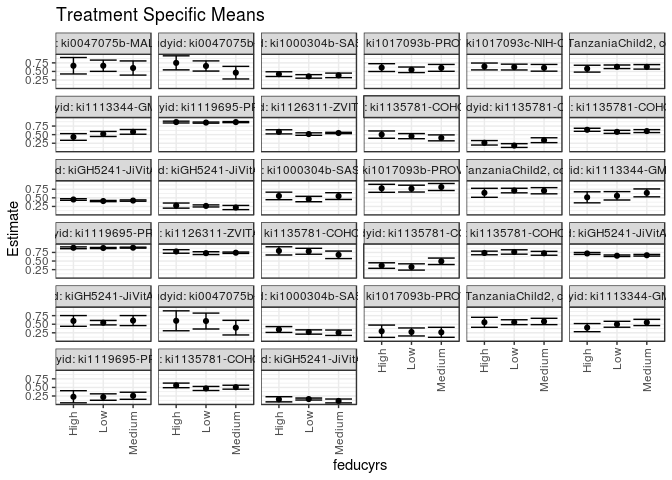

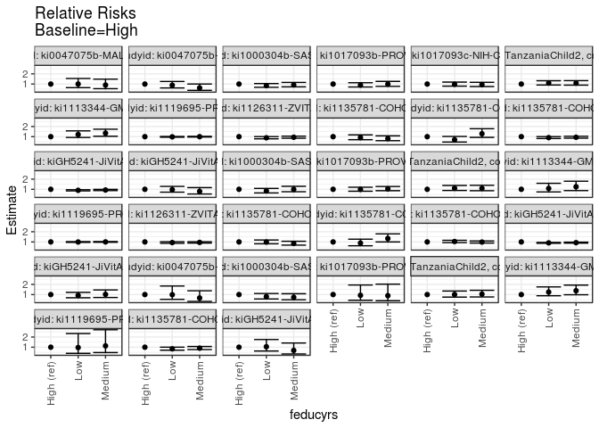

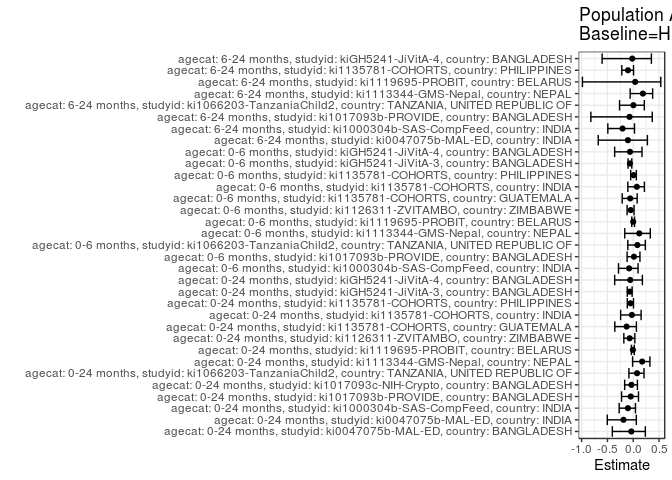

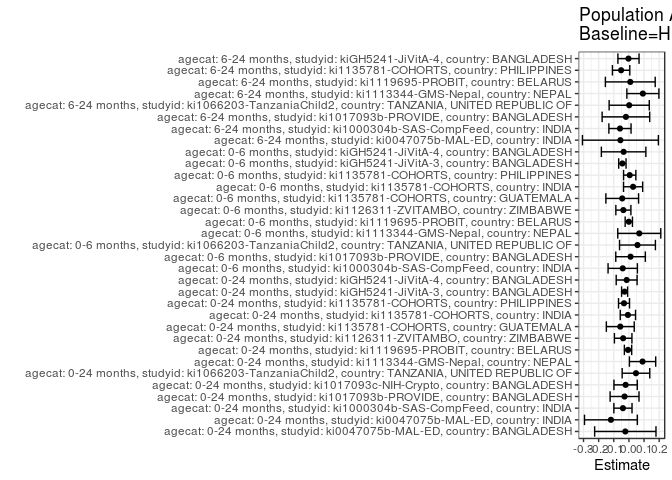

## Results Table

### Parameter: TSM

| agecat | studyid | country | intervention_level | baseline_level | estimate | ci_lower | ci_upper |
| --- | --- | --- | --- | --- | --- | --- | --- |
| 0-24 months | ki0047075b-MAL-ED | BANGLADESH | High | NA | 0.6666667 | 0.4269601 | 0.9063732 |
| 0-24 months | ki0047075b-MAL-ED | BANGLADESH | Low | NA | 0.6666667 | 0.5025048 | 0.8308285 |
| 0-24 months | ki0047075b-MAL-ED | BANGLADESH | Medium | NA | 0.6000000 | 0.3938977 | 0.8061023 |
| 0-24 months | ki0047075b-MAL-ED | INDIA | High | NA | 0.7500000 | 0.5458782 | 0.9541218 |
| 0-24 months | ki0047075b-MAL-ED | INDIA | Low | NA | 0.6595745 | 0.5113855 | 0.8077634 |
| 0-24 months | ki0047075b-MAL-ED | INDIA | Medium | NA | 0.4642857 | 0.2805212 | 0.6480502 |
| 0-24 months | ki1000304b-SAS-CompFeed | INDIA | High | NA | 0.4216824 | 0.3524709 | 0.4908940 |
| 0-24 months | ki1000304b-SAS-CompFeed | INDIA | Low | NA | 0.3558881 | 0.3045400 | 0.4072362 |
| 0-24 months | ki1000304b-SAS-CompFeed | INDIA | Medium | NA | 0.3861604 | 0.3205032 | 0.4518176 |
| 0-24 months | ki1017093b-PROVIDE | BANGLADESH | High | NA | 0.6118193 | 0.4982122 | 0.7254263 |
| 0-24 months | ki1017093b-PROVIDE | BANGLADESH | Low | NA | 0.5480185 | 0.4669197 | 0.6291172 |
| 0-24 months | ki1017093b-PROVIDE | BANGLADESH | Medium | NA | 0.6045518 | 0.5043334 | 0.7047702 |
| 0-24 months | ki1017093c-NIH-Crypto | BANGLADESH | High | NA | 0.6456639 | 0.5457870 | 0.7455408 |
| 0-24 months | ki1017093c-NIH-Crypto | BANGLADESH | Low | NA | 0.6276648 | 0.5438707 | 0.7114589 |
| 0-24 months | ki1017093c-NIH-Crypto | BANGLADESH | Medium | NA | 0.6063876 | 0.5087343 | 0.7040409 |
| 0-24 months | ki1066203-TanzaniaChild2 | TANZANIA, UNITED REPUBLIC OF | High | NA | 0.5807631 | 0.4804398 | 0.6810865 |
| 0-24 months | ki1066203-TanzaniaChild2 | TANZANIA, UNITED REPUBLIC OF | Low | NA | 0.6361280 | 0.5841871 | 0.6880690 |
| 0-24 months | ki1066203-TanzaniaChild2 | TANZANIA, UNITED REPUBLIC OF | Medium | NA | 0.6341332 | 0.5687671 | 0.6994994 |
| 0-24 months | ki1113344-GMS-Nepal | NEPAL | High | NA | 0.4321869 | 0.3347665 | 0.5296074 |
| 0-24 months | ki1113344-GMS-Nepal | NEPAL | Low | NA | 0.5203896 | 0.4467293 | 0.5940499 |
| 0-24 months | ki1113344-GMS-Nepal | NEPAL | Medium | NA | 0.5809274 | 0.5116646 | 0.6501902 |
| 0-24 months | ki1119695-PROBIT | BELARUS | High | NA | 0.8659131 | 0.8396304 | 0.8921958 |
| 0-24 months | ki1119695-PROBIT | BELARUS | Low | NA | 0.8509890 | 0.8343073 | 0.8676707 |
| 0-24 months | ki1119695-PROBIT | BELARUS | Medium | NA | 0.8649461 | 0.8497026 | 0.8801897 |
| 0-24 months | ki1126311-ZVITAMBO | ZIMBABWE | High | NA | 0.5816076 | 0.5213633 | 0.6418519 |
| 0-24 months | ki1126311-ZVITAMBO | ZIMBABWE | Low | NA | 0.5171811 | 0.4810920 | 0.5532703 |
| 0-24 months | ki1126311-ZVITAMBO | ZIMBABWE | Medium | NA | 0.5481671 | 0.5293561 | 0.5669781 |
| 0-24 months | ki1135781-COHORTS | GUATEMALA | High | NA | 0.5011350 | 0.3946391 | 0.6076310 |
| 0-24 months | ki1135781-COHORTS | GUATEMALA | Low | NA | 0.4559680 | 0.3816820 | 0.5302540 |
| 0-24 months | ki1135781-COHORTS | GUATEMALA | Medium | NA | 0.4058675 | 0.3192762 | 0.4924588 |

[output cut: 69 more lines]

### Parameter: E(Y)

| agecat | studyid | country | intervention_level | baseline_level | estimate | ci_lower | ci_upper |
| --- | --- | --- | --- | --- | --- | --- | --- |
| 0-24 months | ki0047075b-MAL-ED | BANGLADESH | NA | NA | 0.6428571 | 0.5282860 | 0.7574282 |
| 0-24 months | ki0047075b-MAL-ED | INDIA | NA | NA | 0.6310680 | 0.5256054 | 0.7365305 |
| 0-24 months | ki1000304b-SAS-CompFeed | INDIA | NA | NA | 0.3822441 | 0.3470990 | 0.4173892 |
| 0-24 months | ki1017093b-PROVIDE | BANGLADESH | NA | NA | 0.5830619 | 0.5262762 | 0.6398476 |
| 0-24 months | ki1017093c-NIH-Crypto | BANGLADESH | NA | NA | 0.6237942 | 0.5698223 | 0.6777662 |
| 0-24 months | ki1066203-TanzaniaChild2 | TANZANIA, UNITED REPUBLIC OF | NA | NA | 0.6272855 | 0.5895954 | 0.6649756 |
| 0-24 months | ki1113344-GMS-Nepal | NEPAL | NA | NA | 0.5223614 | 0.4773383 | 0.5673845 |
| 0-24 months | ki1119695-PROBIT | BELARUS | NA | NA | 0.8600563 | 0.8497279 | 0.8703846 |
| 0-24 months | ki1126311-ZVITAMBO | ZIMBABWE | NA | NA | 0.5436300 | 0.5268423 | 0.5604178 |
| 0-24 months | ki1135781-COHORTS | GUATEMALA | NA | NA | 0.4441341 | 0.3908676 | 0.4974005 |
| 0-24 months | ki1135781-COHORTS | INDIA | NA | NA | 0.2560297 | 0.2186976 | 0.2933617 |
| 0-24 months | ki1135781-COHORTS | PHILIPPINES | NA | NA | 0.6092757 | 0.5839352 | 0.6346162 |
| 0-24 months | kiGH5241-JiVitA-3 | BANGLADESH | NA | NA | 0.4232565 | 0.4119131 | 0.4345998 |
| 0-24 months | kiGH5241-JiVitA-4 | BANGLADESH | NA | NA | 0.2597741 | 0.2335880 | 0.2859602 |
| 0-6 months | ki1000304b-SAS-CompFeed | INDIA | NA | NA | 0.5147059 | 0.4610948 | 0.5683169 |
| 0-6 months | ki1017093b-PROVIDE | BANGLADESH | NA | NA | 0.7880435 | 0.7295878 | 0.8464992 |
| 0-6 months | ki1066203-TanzaniaChild2 | TANZANIA, UNITED REPUBLIC OF | NA | NA | 0.7029412 | 0.6536517 | 0.7522307 |
| 0-6 months | ki1113344-GMS-Nepal | NEPAL | NA | NA | 0.5833333 | 0.5108676 | 0.6557991 |
| 0-6 months | ki1119695-PROBIT | BELARUS | NA | NA | 0.8851500 | 0.8753163 | 0.8949836 |
| 0-6 months | ki1126311-ZVITAMBO | ZIMBABWE | NA | NA | 0.7416564 | 0.7242528 | 0.7590599 |
| 0-6 months | ki1135781-COHORTS | GUATEMALA | NA | NA | 0.7512438 | 0.6914852 | 0.8110023 |
| 0-6 months | ki1135781-COHORTS | INDIA | NA | NA | 0.3954155 | 0.3440450 | 0.4467860 |
| 0-6 months | ki1135781-COHORTS | PHILIPPINES | NA | NA | 0.7402032 | 0.7074271 | 0.7729793 |
| 0-6 months | kiGH5241-JiVitA-3 | BANGLADESH | NA | NA | 0.6768386 | 0.6632567 | 0.6904206 |
| 0-6 months | kiGH5241-JiVitA-4 | BANGLADESH | NA | NA | 0.5606557 | 0.5048650 | 0.6164465 |
| 6-24 months | ki0047075b-MAL-ED | INDIA | NA | NA | 0.5438596 | 0.3951895 | 0.6925298 |
| 6-24 months | ki1000304b-SAS-CompFeed | INDIA | NA | NA | 0.2866242 | 0.2446853 | 0.3285631 |
| 6-24 months | ki1017093b-PROVIDE | BANGLADESH | NA | NA | 0.2764228 | 0.1950773 | 0.3577682 |
| 6-24 months | ki1066203-TanzaniaChild2 | TANZANIA, UNITED REPUBLIC OF | NA | NA | 0.5579515 | 0.5056058 | 0.6102972 |
| 6-24 months | ki1113344-GMS-Nepal | NEPAL | NA | NA | 0.4934037 | 0.4386266 | 0.5481808 |
| 6-24 months | ki1119695-PROBIT | BELARUS | NA | NA | 0.2363636 | 0.1715730 | 0.3011543 |
| 6-24 months | ki1135781-COHORTS | PHILIPPINES | NA | NA | 0.5073446 | 0.4725123 | 0.5421770 |
| 6-24 months | kiGH5241-JiVitA-4 | BANGLADESH | NA | NA | 0.1513002 | 0.1269239 | 0.1756766 |

### Parameter: RR

| agecat | studyid | country | intervention_level | baseline_level | estimate | ci_lower | ci_upper |
| --- | --- | --- | --- | --- | --- | --- | --- |
| 0-24 months | ki0047075b-MAL-ED | BANGLADESH | High | High | 1.0000000 | 1.0000000 | 1.0000000 |
| 0-24 months | ki0047075b-MAL-ED | BANGLADESH | Low | High | 1.0000000 | 0.6465372 | 1.5467015 |
| 0-24 months | ki0047075b-MAL-ED | BANGLADESH | Medium | High | 0.9000000 | 0.5471431 | 1.4804171 |
| 0-24 months | ki0047075b-MAL-ED | INDIA | High | High | 1.0000000 | 1.0000000 | 1.0000000 |
| 0-24 months | ki0047075b-MAL-ED | INDIA | Low | High | 0.8794326 | 0.6179291 | 1.2516028 |
| 0-24 months | ki0047075b-MAL-ED | INDIA | Medium | High | 0.6190476 | 0.3826504 | 1.0014883 |
| 0-24 months | ki1000304b-SAS-CompFeed | INDIA | High | High | 1.0000000 | 1.0000000 | 1.0000000 |
| 0-24 months | ki1000304b-SAS-CompFeed | INDIA | Low | High | 0.8439719 | 0.6792768 | 1.0485983 |
| 0-24 months | ki1000304b-SAS-CompFeed | INDIA | Medium | High | 0.9157612 | 0.7245507 | 1.1574325 |
| 0-24 months | ki1017093b-PROVIDE | BANGLADESH | High | High | 1.0000000 | 1.0000000 | 1.0000000 |
| 0-24 months | ki1017093b-PROVIDE | BANGLADESH | Low | High | 0.8957195 | 0.7100178 | 1.1299906 |
| 0-24 months | ki1017093b-PROVIDE | BANGLADESH | Medium | High | 0.9881215 | 0.7746650 | 1.2603953 |
| 0-24 months | ki1017093c-NIH-Crypto | BANGLADESH | High | High | 1.0000000 | 1.0000000 | 1.0000000 |
| 0-24 months | ki1017093c-NIH-Crypto | BANGLADESH | Low | High | 0.9721231 | 0.7935722 | 1.1908472 |
| 0-24 months | ki1017093c-NIH-Crypto | BANGLADESH | Medium | High | 0.9391692 | 0.7534708 | 1.1706342 |
| 0-24 months | ki1066203-TanzaniaChild2 | TANZANIA, UNITED REPUBLIC OF | High | High | 1.0000000 | 1.0000000 | 1.0000000 |
| 0-24 months | ki1066203-TanzaniaChild2 | TANZANIA, UNITED REPUBLIC OF | Low | High | 1.0953313 | 0.9049647 | 1.3257430 |
| 0-24 months | ki1066203-TanzaniaChild2 | TANZANIA, UNITED REPUBLIC OF | Medium | High | 1.0918965 | 0.8931708 | 1.3348377 |
| 0-24 months | ki1113344-GMS-Nepal | NEPAL | High | High | 1.0000000 | 1.0000000 | 1.0000000 |
| 0-24 months | ki1113344-GMS-Nepal | NEPAL | Low | High | 1.2040846 | 0.9227054 | 1.5712706 |
| 0-24 months | ki1113344-GMS-Nepal | NEPAL | Medium | High | 1.3441577 | 1.0417707 | 1.7343164 |
| 0-24 months | ki1119695-PROBIT | BELARUS | High | High | 1.0000000 | 1.0000000 | 1.0000000 |
| 0-24 months | ki1119695-PROBIT | BELARUS | Low | High | 0.9827649 | 0.9480429 | 1.0187585 |
| 0-24 months | ki1119695-PROBIT | BELARUS | Medium | High | 0.9988833 | 0.9646127 | 1.0343714 |
| 0-24 months | ki1126311-ZVITAMBO | ZIMBABWE | High | High | 1.0000000 | 1.0000000 | 1.0000000 |
| 0-24 months | ki1126311-ZVITAMBO | ZIMBABWE | Low | High | 0.8892270 | 0.7863985 | 1.0055012 |
| 0-24 months | ki1126311-ZVITAMBO | ZIMBABWE | Medium | High | 0.9425034 | 0.8469137 | 1.0488822 |
| 0-24 months | ki1135781-COHORTS | GUATEMALA | High | High | 1.0000000 | 1.0000000 | 1.0000000 |
| 0-24 months | ki1135781-COHORTS | GUATEMALA | Low | High | 0.9098706 | 0.7038260 | 1.1762346 |
| 0-24 months | ki1135781-COHORTS | GUATEMALA | Medium | High | 0.8098964 | 0.6059064 | 1.0825635 |

[output cut: 69 more lines]

### Parameter: PAR

| agecat | studyid | country | intervention_level | baseline_level | estimate | ci_lower | ci_upper |
| --- | --- | --- | --- | --- | --- | --- | --- |
| 0-24 months | ki0047075b-MAL-ED | BANGLADESH | High | NA | -0.0238095 | -0.2265022 | 0.1788831 |
| 0-24 months | ki0047075b-MAL-ED | INDIA | High | NA | -0.1189320 | -0.2936260 | 0.0557619 |
| 0-24 months | ki1000304b-SAS-CompFeed | INDIA | High | NA | -0.0394383 | -0.0994199 | 0.0205433 |
| 0-24 months | ki1017093b-PROVIDE | BANGLADESH | High | NA | -0.0287574 | -0.1242277 | 0.0667129 |
| 0-24 months | ki1017093c-NIH-Crypto | BANGLADESH | High | NA | -0.0218697 | -0.0989119 | 0.0551725 |
| 0-24 months | ki1066203-TanzaniaChild2 | TANZANIA, UNITED REPUBLIC OF | High | NA | 0.0465224 | -0.0446445 | 0.1376892 |
| 0-24 months | ki1113344-GMS-Nepal | NEPAL | High | NA | 0.0901745 | 0.0033212 | 0.1770277 |
| 0-24 months | ki1119695-PROBIT | BELARUS | High | NA | -0.0058569 | -0.0300413 | 0.0183276 |
| 0-24 months | ki1126311-ZVITAMBO | ZIMBABWE | High | NA | -0.0379776 | -0.0958812 | 0.0199261 |
| 0-24 months | ki1135781-COHORTS | GUATEMALA | High | NA | -0.0570010 | -0.1491491 | 0.0351472 |
| 0-24 months | ki1135781-COHORTS | INDIA | High | NA | -0.0067640 | -0.0573246 | 0.0437966 |
| 0-24 months | ki1135781-COHORTS | PHILIPPINES | High | NA | -0.0322902 | -0.0686447 | 0.0040642 |
| 0-24 months | kiGH5241-JiVitA-3 | BANGLADESH | High | NA | -0.0285355 | -0.0483821 | -0.0086889 |
| 0-24 months | kiGH5241-JiVitA-4 | BANGLADESH | High | NA | -0.0149821 | -0.0839860 | 0.0540219 |
| 0-6 months | ki1000304b-SAS-CompFeed | INDIA | High | NA | -0.0408443 | -0.1377572 | 0.0560686 |
| 0-6 months | ki1017093b-PROVIDE | BANGLADESH | High | NA | 0.0108808 | -0.0868458 | 0.1086075 |
| 0-6 months | ki1066203-TanzaniaChild2 | TANZANIA, UNITED REPUBLIC OF | High | NA | 0.0565590 | -0.0620349 | 0.1751529 |
| 0-6 months | ki1113344-GMS-Nepal | NEPAL | High | NA | 0.0684242 | -0.0737398 | 0.2105882 |
| 0-6 months | ki1119695-PROBIT | BELARUS | High | NA | -0.0006788 | -0.0247676 | 0.0234101 |
| 0-6 months | ki1126311-ZVITAMBO | ZIMBABWE | High | NA | -0.0365803 | -0.0863352 | 0.0131747 |
| 0-6 months | ki1135781-COHORTS | GUATEMALA | High | NA | -0.0442108 | -0.1522742 | 0.0638527 |
| 0-6 months | ki1135781-COHORTS | INDIA | High | NA | 0.0276495 | -0.0355563 | 0.0908554 |
| 0-6 months | ki1135781-COHORTS | PHILIPPINES | High | NA | 0.0052753 | -0.0353427 | 0.0458932 |
| 0-6 months | kiGH5241-JiVitA-3 | BANGLADESH | High | NA | -0.0432757 | -0.0675710 | -0.0189805 |
| 0-6 months | kiGH5241-JiVitA-4 | BANGLADESH | High | NA | -0.0349893 | -0.1820430 | 0.1120645 |
| 6-24 months | ki0047075b-MAL-ED | INDIA | High | NA | -0.0561404 | -0.3070550 | 0.1947743 |
| 6-24 months | ki1000304b-SAS-CompFeed | INDIA | High | NA | -0.0591625 | -0.1324301 | 0.0141052 |
| 6-24 months | ki1017093b-PROVIDE | BANGLADESH | High | NA | -0.0198735 | -0.1770318 | 0.1372847 |
| 6-24 months | ki1066203-TanzaniaChild2 | TANZANIA, UNITED REPUBLIC OF | High | NA | 0.0019067 | -0.1307523 | 0.1345658 |
| 6-24 months | ki1113344-GMS-Nepal | NEPAL | High | NA | 0.0923270 | -0.0136009 | 0.1982549 |
| 6-24 months | ki1119695-PROBIT | BELARUS | High | NA | 0.0090909 | -0.1555312 | 0.1737130 |
| 6-24 months | ki1135781-COHORTS | PHILIPPINES | High | NA | -0.0515948 | -0.1089727 | 0.0057830 |
| 6-24 months | kiGH5241-JiVitA-4 | BANGLADESH | High | NA | -0.0028749 | -0.0727334 | 0.0669836 |

### Parameter: PAF

| agecat | studyid | country | intervention_level | baseline_level | estimate | ci_lower | ci_upper |
| --- | --- | --- | --- | --- | --- | --- | --- |
| 0-24 months | ki0047075b-MAL-ED | BANGLADESH | High | NA | -0.0370370 | -0.4049867 | 0.2345509 |
| 0-24 months | ki0047075b-MAL-ED | INDIA | High | NA | -0.1884615 | -0.5024086 | 0.0598823 |
| 0-24 months | ki1000304b-SAS-CompFeed | INDIA | High | NA | -0.1031757 | -0.2722451 | 0.0434260 |
| 0-24 months | ki1017093b-PROVIDE | BANGLADESH | High | NA | -0.0493213 | -0.2263158 | 0.1021276 |
| 0-24 months | ki1017093c-NIH-Crypto | BANGLADESH | High | NA | -0.0350592 | -0.1658138 | 0.0810304 |
| 0-24 months | ki1066203-TanzaniaChild2 | TANZANIA, UNITED REPUBLIC OF | High | NA | 0.0741646 | -0.0835313 | 0.2089097 |
| 0-24 months | ki1113344-GMS-Nepal | NEPAL | High | NA | 0.1726285 | -0.0121542 | 0.3236766 |
| 0-24 months | ki1119695-PROBIT | BELARUS | High | NA | -0.0068099 | -0.0353261 | 0.0209209 |
| 0-24 months | ki1126311-ZVITAMBO | ZIMBABWE | High | NA | -0.0698592 | -0.1818853 | 0.0315484 |
| 0-24 months | ki1135781-COHORTS | GUATEMALA | High | NA | -0.1283418 | -0.3567818 | 0.0616360 |
| 0-24 months | ki1135781-COHORTS | INDIA | High | NA | -0.0264188 | -0.2439045 | 0.1530415 |
| 0-24 months | ki1135781-COHORTS | PHILIPPINES | High | NA | -0.0529977 | -0.1144364 | 0.0050538 |
| 0-24 months | kiGH5241-JiVitA-3 | BANGLADESH | High | NA | -0.0674188 | -0.1153555 | -0.0215424 |
| 0-24 months | kiGH5241-JiVitA-4 | BANGLADESH | High | NA | -0.0576734 | -0.3595741 | 0.1771886 |
| 0-6 months | ki1000304b-SAS-CompFeed | INDIA | High | NA | -0.0793546 | -0.2854384 | 0.0936895 |
| 0-6 months | ki1017093b-PROVIDE | BANGLADESH | High | NA | 0.0138074 | -0.1183885 | 0.1303775 |
| 0-6 months | ki1066203-TanzaniaChild2 | TANZANIA, UNITED REPUBLIC OF | High | NA | 0.0804605 | -0.1051474 | 0.2348958 |
| 0-6 months | ki1113344-GMS-Nepal | NEPAL | High | NA | 0.1172986 | -0.1642743 | 0.3307748 |
| 0-6 months | ki1119695-PROBIT | BELARUS | High | NA | -0.0007668 | -0.0283544 | 0.0260807 |
| 0-6 months | ki1126311-ZVITAMBO | ZIMBABWE | High | NA | -0.0493224 | -0.1187032 | 0.0157555 |
| 0-6 months | ki1135781-COHORTS | GUATEMALA | High | NA | -0.0588501 | -0.2133559 | 0.0759813 |
| 0-6 months | ki1135781-COHORTS | INDIA | High | NA | 0.0699253 | -0.1045777 | 0.2168600 |
| 0-6 months | ki1135781-COHORTS | PHILIPPINES | High | NA | 0.0071268 | -0.0492954 | 0.0605151 |
| 0-6 months | kiGH5241-JiVitA-3 | BANGLADESH | High | NA | -0.0639380 | -0.1005328 | -0.0285601 |
| 0-6 months | kiGH5241-JiVitA-4 | BANGLADESH | High | NA | -0.0624077 | -0.3601317 | 0.1701464 |
| 6-24 months | ki0047075b-MAL-ED | INDIA | High | NA | -0.1032258 | -0.6778110 | 0.2745862 |
| 6-24 months | ki1000304b-SAS-CompFeed | INDIA | High | NA | -0.2064112 | -0.4923967 | 0.0247713 |
| 6-24 months | ki1017093b-PROVIDE | BANGLADESH | High | NA | -0.0718954 | -0.8212752 | 0.3691454 |
| 6-24 months | ki1066203-TanzaniaChild2 | TANZANIA, UNITED REPUBLIC OF | High | NA | 0.0034174 | -0.2651307 | 0.2149611 |
| 6-24 months | ki1113344-GMS-Nepal | NEPAL | High | NA | 0.1871227 | -0.0593886 | 0.3762728 |
| 6-24 months | ki1119695-PROBIT | BELARUS | High | NA | 0.0384615 | -0.9840988 | 0.5340171 |
| 6-24 months | ki1135781-COHORTS | PHILIPPINES | High | NA | -0.1016958 | -0.2211622 | 0.0060832 |
| 6-24 months | kiGH5241-JiVitA-4 | BANGLADESH | High | NA | -0.0190012 | -0.6029359 | 0.3522115 |